# Emulation

JS

Updated: 27/8/26, with mean functions and ability to select multiple different emulator assumptions within the same call of `FitEmulators`.

This example demonstrates some of the emulation functionality using a set of simulations from a pulmonary circulation model. Other aspects of this dataset are shown in `full_workflow.html`.

Load in design, data:

```r
setwd('..')
tmp <- getwd()
source(paste0(tmp, '/plot.R'))
source(paste0(tmp, '/basis.R'))
source(paste0(tmp, '/emulate.R'))
source(paste0(tmp, '/calibrate.R'))
load(paste0(tmp, '/data/SECRET_data.RData'))
# Currently need to load ggplot2 explicitly
library(ggplot2)
```

Scaling the design to [0,1] using the provided parameter ranges:

```r
scaled_design <- ScaleInputs(design[,1:4], parRanges, c(0,1))
```

We’ll create 2 objects to demonstrate emulation. Firstly, calculate the SVD and coefficients:

```r
flow1_basis <- MakeDataBasis(flow1_data)
flow1_basis$grid <- data.frame(Time = seq(from=0,by = 0.01, len = 512))
flow1_coeffs <- GetEmData(scaled_design, flow1_basis, q = 5)
head(flow1_coeffs)
```

```
##         kMV      alpha       lrrA      lrrV         C1         C2         C3
## 1 0.2947210 0.08288013 0.62378109 0.3207808 -57.654972 -21.804896   9.724607
## 2 0.9652367 0.06777972 0.38185132 0.6951411 -20.741136 -32.018533  -9.987071
## 3 0.6105418 0.69884483 0.05439422 0.8660534  47.747129   1.772807 -19.527830
## 4 0.1562447 0.01730095 0.31641006 0.5044971 -51.121585  -7.456377  15.738800
## 5 0.6351484 0.63567131 0.55211716 0.1662941  21.977666 -18.626407  -6.811848
## 6 0.3784997 0.73657700 0.72578984 0.3711951  -5.173414  21.054044  -2.062772
##           C4        C5
## 1   1.470627 -6.743898
## 2  10.134155  6.463637
## 3  -6.458404  8.086397
## 4 -13.113496  2.551755
## 5  -6.335217 -9.934757
## 6  -4.182515 -2.972536
```

The dataset we’ve created here contains the 4 inputs, followed by the 5 leading basis coefficients, for each of the 100 simulations in turn.

And alternatively, select a subset of timepoints:

```r
time_inds <- c(50,150,300,500)
flow1_time <- data.frame(scaled_design,
                         t50 = flow1_data[time_inds[1],],
                         t150 = flow1_data[time_inds[2],],
                         t300 = flow1_data[time_inds[3],],
                         t500 = flow1_data[time_inds[4],])
head(flow1_time)
```

```
##         kMV      alpha       lrrA      lrrV        t50     t150      t300
## 1 0.2947210 0.08288013 0.62378109 0.3207808  1.5181817 11.95119  9.842022
## 2 0.9652367 0.06777972 0.38185132 0.6951411  1.5239613 14.87948 10.694232
## 3 0.6105418 0.69884483 0.05439422 0.8660534 -1.7263772 20.92839  9.137437
## 4 0.1562447 0.01730095 0.31641006 0.5044971  1.6317760 13.46548  9.802914
## 5 0.6351484 0.63567131 0.55211716 0.1662941 -1.6552501 16.97342  8.893376
## 6 0.3784997 0.73657700 0.72578984 0.3711951 -0.7360757 17.84778  8.096398
##         t500
## 1  4.2275806
## 2  2.9091467
## 3 -3.2097102
## 4  3.1575479
## 5 -0.9904278
## 6 -0.9175514
```

Similarly, each row here is a different simulation, containing the 4 inputs, and the 4 quantities (timepoints) we’ve decided to emulate.

Splitting into train/validation for later:

```r
tt <- TrainTestSplit(scaled_design, seed = 58219)
train_inds <- tt$train_inds
val_inds <- tt$val_inds
```

## Default emulation

`FitEmulators` is the main function for training emulators.

If we just apply it to our data above, providing no other information and hence using the default settings:

```r
em_time <- FitEmulators(flow1_time[train_inds,])
em_coeffs <- FitEmulators(flow1_coeffs[train_inds,])
```

Comparing what’s been fitted:

```r
summary(em_time)
```

```
##            Length Class      Mode
## em         1      rgasp      S4
## method     1      -none-     character
## response   1      -none-     character
## mean_fn    1      -none-     character
## train_data 8      data.frame list
```

```r
em_time$response
```

```
## [1] "t500"
```

```r
summary(em_coeffs)
```

```
##      Length Class  Mode
## [1,] 5      -none- list
## [2,] 5      -none- list
## [3,] 5      -none- list
## [4,] 5      -none- list
## [5,] 5      -none- list
```

```r
unlist(lapply(1:5, function(k) em_coeffs[[k]]$response))
```

```
## [1] "C1" "C2" "C3" "C4" "C5"
```

This highlights a key difference in the default behaviour:

- If the provided data includes a column named `C1`, `FitEmulators` will automatically set all preceding columns as the emulator inputs, and will train emulators for `C1` **and all subsequent columns**. Here, `flow1_coeffs` contains the leading 5 coefficients, hence 5 emulators have been trained.
- There’s no column named `C1` in `flow1_time`. Given no other information, `FitEmulators` assumes the final column is the target output, and all preceding columns are inputs. Therefore, in the emulator `em_time` fitted above, `t50`, `t150` and `t300` have been included as predictors (along with the 4 actual inputs) for emulating `t500`:

```r
em_time$em
```

```
##
## Call:
## RobustGaSP::rgasp(design = tData_input, response = tData_response,
##     nugget.est = nugget, kernel_type = covariance)
## Mean parameters:  -2.791063
## Variance parameter:  87.73041
## Range parameters:  3.750033 4.673904 8.141397 3.355738 21.71075 69.09918 15.16263
## Noise parameter:  0.001404689
```

To instead get what we obviously intend here (emulate each of the 4 time points using the 4 input columns), we need to provide some extra information. First, we can point towards which columns are inputs:

```r
em_time <- FitEmulators(flow1_time[train_inds,], input = 1:4)
```

```r
summary(em_time)
```

```
##            Length Class      Mode
## em         1      rgasp      S4
## method     1      -none-     character
## response   1      -none-     character
## mean_fn    1      -none-     character
## train_data 5      data.frame list
```

```r
em_time$response
```

```
## [1] "t500"
```

This still fits a single emulator (for `t500` only), but now only uses the first 4 columns as inputs.

To finally emulate all 4 outputs:

```r
em_time <- FitEmulators(flow1_time[train_inds,], input = 1:4, output = c('t50', 't150', 't300', 't500'))
```

```r
summary(em_time)
```

```
##      Length Class  Mode
## [1,] 5      -none- list
## [2,] 5      -none- list
## [3,] 5      -none- list
## [4,] 5      -none- list
```

```r
unlist(lapply(1:4, function(k) em_time[[k]]$response))
```

```
## [1] "t50"  "t150" "t300" "t500"
```

Alternatively, we can select the outputs with column indices, or the inputs with column names:

```r
em_time <- FitEmulators(flow1_time[train_inds,], input = c('kMV','alpha','lrrA','lrrV'), output = 5:8)
```

```r
summary(em_time)
```

```
##      Length Class  Mode
## [1,] 5      -none- list
## [2,] 5      -none- list
## [3,] 5      -none- list
## [4,] 5      -none- list
```

```r
unlist(lapply(1:4, function(k) em_time[[k]]$response))
```

```
## [1] "t50"  "t150" "t300" "t500"
```

Any combination of `input`, `output` as numeric or character vectors are accepted, so long as any named columns and column indices exist in `tData`. If we try to select a column that doesn’t exist:

```r
try(FitEmulators(flow1_time[train_inds,], input = 1:4, output = 'something'))
```

```
## Error in FitEmulators(flow1_time[train_inds, ], input = 1:4, output = "something") :
##   tData is missing the following outputs that were chosen to be emulated, please provide or select different outputs: something
```

Selecting the same column as both an input and output is also not acceptable:

```r
try(FitEmulators(flow1_time[train_inds,], input = 1:4, output = 4))
```

```
## Error in FitEmulators(flow1_time[train_inds, ], input = 1:4, output = 4) :
##   Following columns have been included as both input and output, please refine: lrrV
```

Specifying `input` and `output` using column names rather than indices is generally more robust, and will flag if there’s a missing name. Selecting using indices will only flag an issue if one or more is out-of-bounds, or if any are present in both the input and output set, but relies on the ordering of the training data being as expected.

## Plotting emulators

The two main things we might want to immediately consider are leave-one-outs and predictions on some out-of-sample set.

We can produce these for an individual emulator:

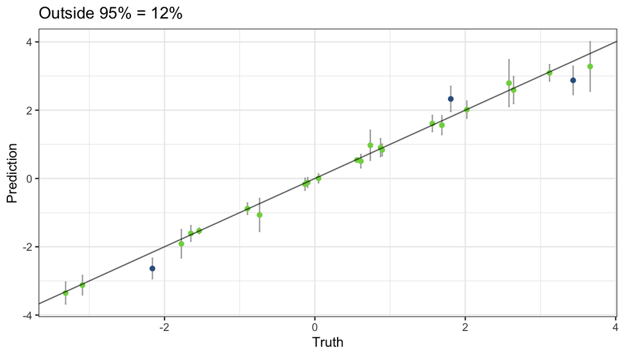

```r
Validate(em_time[[1]], flow1_time[val_inds,])
```

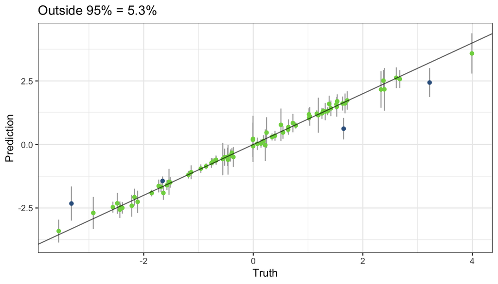

```r
LeaveOneOut(em_time[[1]])
```

Or for multiple (recommended to store as a named object, as it will return each plot in a list, but also immediately print all in a single plot):

```r
val_time <- Validate(em_time, flow1_time[val_inds,])
```

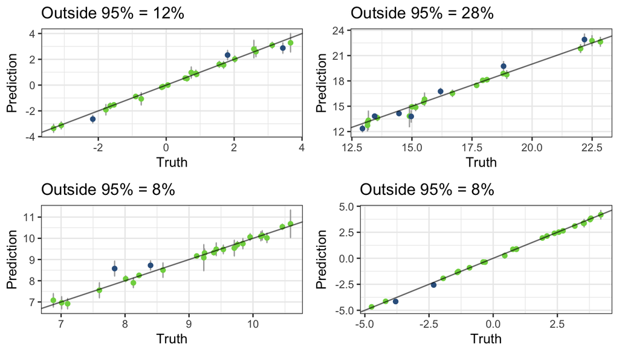

```r
summary(val_time)
```

```
##      Length Class Mode
## [1,] 11     gg    list
## [2,] 11     gg    list
## [3,] 11     gg    list
## [4,] 11     gg    list
```

```r
loo_time <- LeaveOneOut(em_time)
```

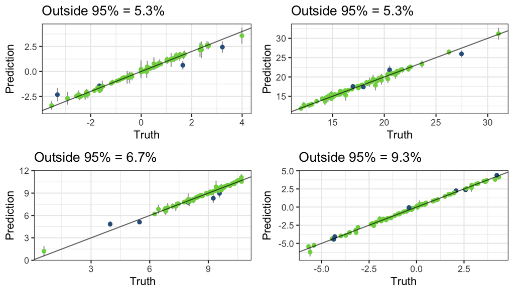

There’s other plotting options, e.g., ordering by index instead:

```r
val_time <- Validate(em_time, flow1_time[val_inds,], by_index = TRUE)
```

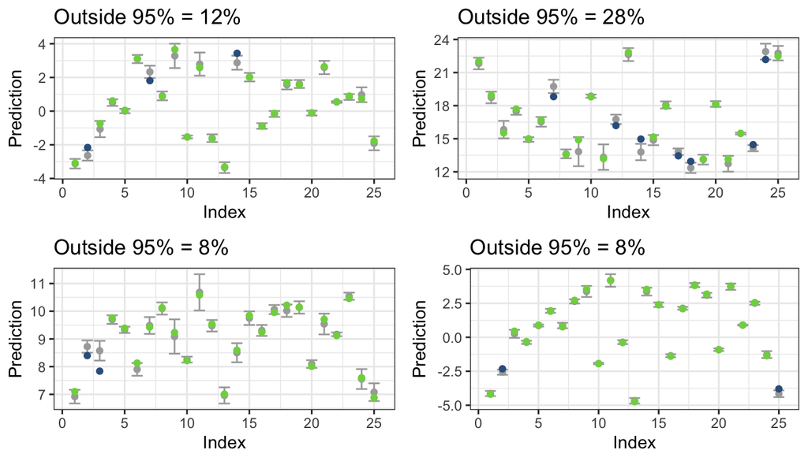

And/or by input:

```r
val_time <- Validate(em_time, flow1_time[val_inds,], by_index = TRUE, by_input = TRUE)
```

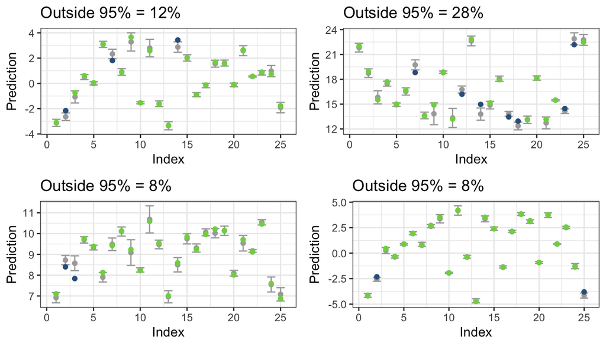

This doesn’t automatically print all plots, but the `by_input` plots can be found via:

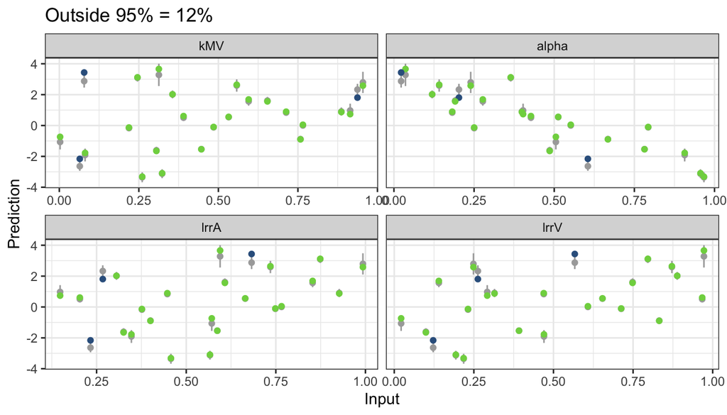

```r
val_time[[1]]$input
```

## Using different emulator types

We could directly compare different methods for emulating the same output. We could use `FitEmulators` as follows to fit for 4 different methods:

(Not run: `dgpsi`, used by `method = gp` and `method = dgp`, doesn’t work currently in RMd. Running the below code in `R` as normal will work.)

```r
# inputs <- colnames(scaled_design)
# emC1_v1 <- FitEmulators(flow1_coeffs[train_inds,], method = 'rgasp', input = inputs, output = 'C1')
# emC1_v2 <- FitEmulators(flow1_coeffs[train_inds,], method = 'het', input = inputs, output = 'C1')
# emC1_v3 <- FitEmulators(flow1_coeffs[train_inds,], method = 'gp', input = inputs, output = 'C1')
# emC1_v4 <- FitEmulators(flow1_coeffs[train_inds,], method = 'dgp', input = inputs, output = 'C1')
```

And can then combine these into a single list to enable us to use the plotting functions as before:

```r
# emC1 <- list(emC1_v1, emC1_v2, emC1_v3, emC1_v4)
# val_C1 <- Validate(emC1, flow1_coeffs[val_inds,], by_index = TRUE)
```

It is not currently possible to fit emulators using multiple different packages in a single call of `FitEmulators`, and the above multiple calls and post-processing are required if we wish to do so. However, given a certain fitting method, we can specify different mean and covariance functions, nuggets, and active input sets for each output (see below).

Generally, it makes sense to use the same fitting method for all outputs initially, before refining any that need it later, via `RefitEmulator`. Prediction, validation etc. all work in the usual way, regardless of whether each individual emulator has been fitted with a different method.

## Refitting a specific emulator

We can replace the existing emulator for `t150` with a version refitted with different assumptions via:

```r
em_time <- RefitEmulator(em_time, 't150', method = 'het')
```

Instead of `rgasp`, we’re tried fitting using `hetGP` instead. Reproducing the validation plots from before, we see the 2nd has been switched with the new emulator:

```r
val_time <- Validate(em_time, flow1_time[val_inds,], by_index = TRUE)
```

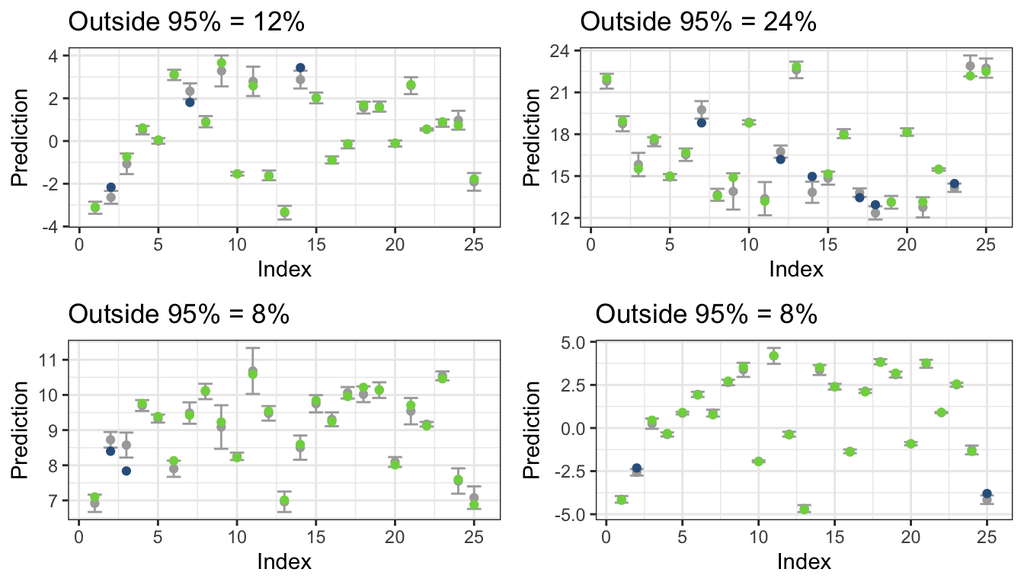

At least when considering the 25 validation points, this has improved predictions slightly.

## Changing emulator assumptions

It’s possible to provide different assumptions about the covariance function, nugget, input set, and mean function, whether emulating a single output or multiple.

If we provide a vector of $k$ outputs to be emulated, for each of a) mean function, b) covariance function, c) whether to include a nugget, and d) set of inputs, we need to provide either:

- A single choice, which is assumed to be common to each emulator, or
- A vector of length $k$ (in the case of `mean_fn`, `covariance` or `nugget`), or a list of length $k$ (`input`).

All combinations are possible. For example, we could choose specific mean and covariance functions for each of the $k$ outputs we’re emulating, but simply set `nugget = TRUE` to universally assume this.

The subsections below give examples of how to vary each of these options.

### Different input sets

To use different sets of input parameters across outputs, we can provide a list that contains either a character or numeric vector relating to the columns of the training dataset, relating to each chosen output.

This may be useful because we’re emulating different outputs where there are different active sets of inputs, or perhaps we wish to compare different assumptions for emulating the same output. I’ll do the latter here, and fit a constant mean emulator to `C1` with different sets of inputs included.

If we provide a list of input sets, but just a single output, this gives an error as 4 input sets have been provided, but only 1 output (if this were the other way around, with 4 outputs and a single input set, as above this will assume each output has the same set of inputs, and will work fine. The general behaviour is to duplicate input assumptions where needed, but not to automatically duplicate outputs):

```r
inputs <- colnames(scaled_design)
try(FitEmulators(flow1_coeffs[train_inds,], method = 'rgasp', input = list(inputs[4],inputs[3:4],inputs[2:4],inputs), output = 'C1'))
```

```
## Error in FitEmulators(flow1_coeffs[train_inds, ], method = "rgasp", input = list(inputs[4],  :
##   Number of provided input sets needs to be either a single vector, or a list of vectors with length equal to the number of outputs.
```

Instead, explicitly repeating the same output 4 times means that each input set (and any other combination of assumptions we provide) will be used to emulate `C1` each time:

```r
emC1 <- FitEmulators(flow1_coeffs[train_inds,], method = 'rgasp', input = list(inputs[4],inputs[3:4],inputs[2:4],inputs), output = rep('C1',4))
```

```r
val_C1 <- Validate(emC1, flow1_coeffs[val_inds,], by_index = TRUE)
```

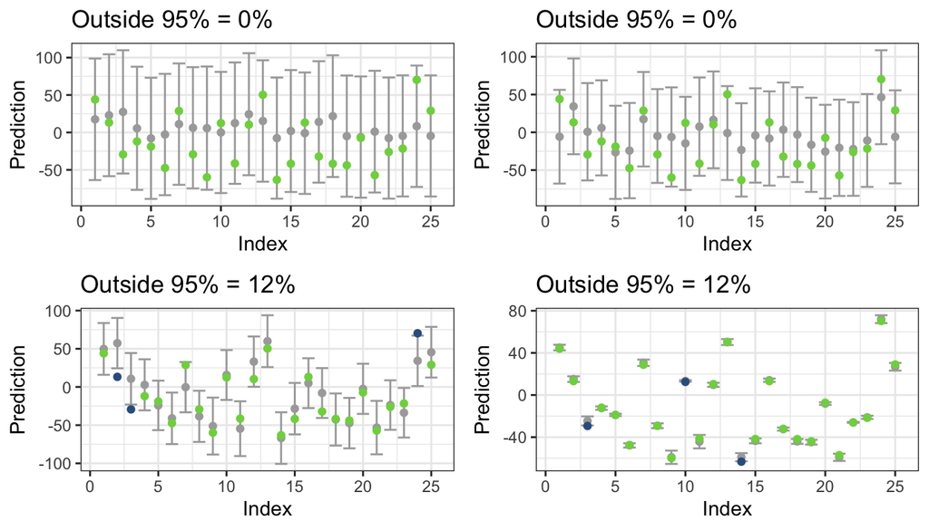

Training an emulator using only the 4th input is not particularly useful, and using the 3rd and 4th only doesn’t do much better.

### Different covariance functions

A few covariance functions are currently possible (Matern 3/2, Matern 5/2, squared exponential), with the default currently Matern 5/2. Each underlying package names the covariance functions differently (below, written as `rgasp` accepts them), however `FitEmulators` accepts a range of naming conventions and converts them appropriately (see source code / help file for exhaustive list).

Here emulating `C1` with each of the 3 covariance functions, keeping all other assumptions the same:

```r
emC1 <- FitEmulators(flow1_coeffs[train_inds,], method = 'rgasp', input = inputs, covariance = c('matern5_2', 'matern3_2', 'sexp'), output = rep('C1', 3))
val_C1 <- Validate(emC1, flow1_coeffs[val_inds,], by_index = TRUE)
```

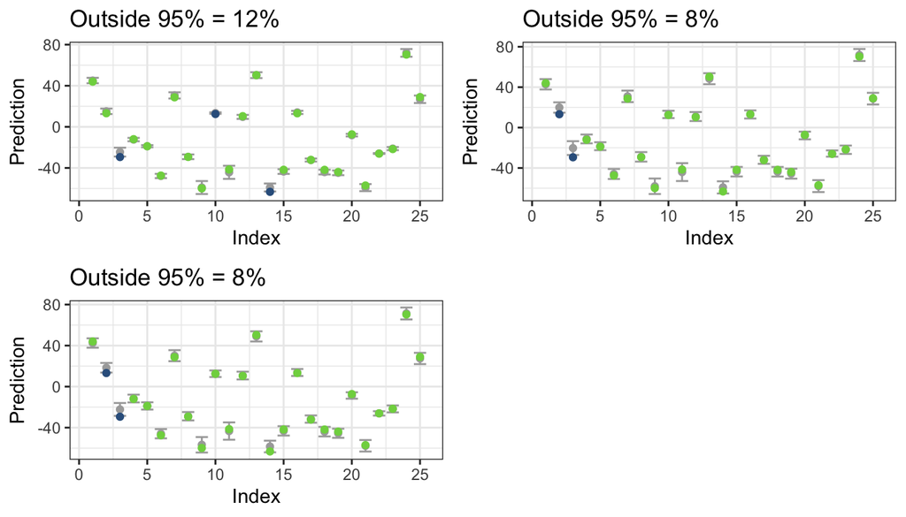

### Different mean functions

Mean functions can be provided in a similar way. The possible options are:

- `constant`: assumes a constant mean;
- `linear`: assumes a mean that is linear in the inputs;
- `formula`: any other formula can be given, provided each of the inputs included in it are named in the training data frame. Any formula that can be provided to `lm` can be used here. The response and `~` should not be included.

Training emulators to `C1` with 4 different mean function arguments. The 2nd and 3rd are identical as an illustration:

```r
mean_fn_vector <- c('constant',
                  'linear',
                  'lrrV+kMV+alpha+lrrA',
                  'I(kMV^2) + I(alpha^2)')

emC1 <- FitEmulators(flow1_coeffs[train_inds,], method = 'rgasp', input = inputs, output = rep('C1',4), mean_fn = mean_fn_vector)
val_C1 <- Validate(emC1, flow1_coeffs[val_inds,], by_index = TRUE)
```

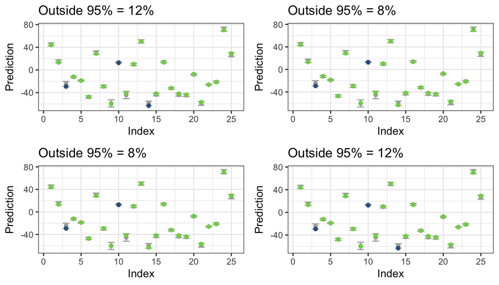

```r
loo_C1 <- LeaveOneOut(emC1, by_index = TRUE)
```

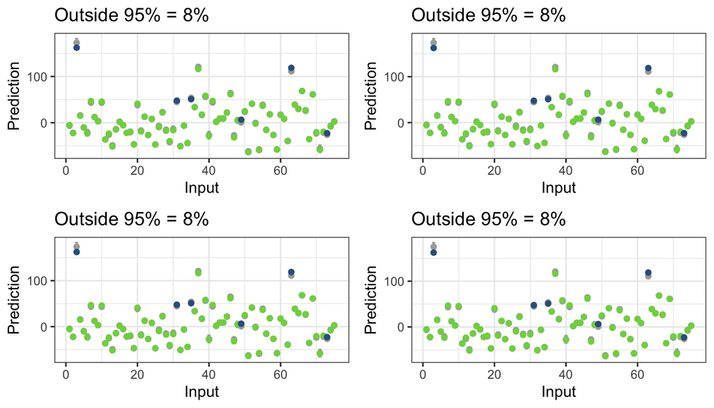

To more clearly verify that the 2nd and 3rd are identical as expected, we can produce predictions for the validation set:

```r
preds <- Predict(emC1, flow1_coeffs[val_inds,])
head(preds$Expectation)
```

```
##           [,1]      [,2]      [,3]      [,4]
## [1,]  45.06362  44.94720  44.94720  45.04600
## [2,]  15.12210  15.31368  15.31368  15.14063
## [3,] -24.57529 -24.61966 -24.61966 -24.60535
## [4,] -12.40742 -12.42684 -12.42684 -12.41346
## [5,] -18.86430 -18.78123 -18.78123 -18.83969
## [6,] -47.81169 -47.07928 -47.07928 -47.73466
```

```r
head(preds$Variance)
```

```
##           [,1]      [,2]      [,3]      [,4]
## [1,] 1.8277995 1.9833357 1.9833357 1.8856347
## [2,] 1.8816933 2.0958396 2.0958396 1.9588588
## [3,] 4.8643493 5.5443786 5.5443786 5.0793539
## [4,] 0.7071314 0.8890409 0.8890409 0.7462925
## [5,] 0.3042505 0.3474110 0.3474110 0.3136839
## [6,] 1.1300588 1.2695878 1.2695878 1.1622605
```

and the 2nd and 3rd columns are exactly the same for both the expectation and variance.

Aside: we should also get identical predictions if the validation dataset is provided with columns re-ordered:

```r
preds2 <- Predict(emC1, flow1_coeffs[val_inds,9:1])
summary(c(preds$Expectation - preds2$Expectation))
```

```
##    Min. 1st Qu.  Median    Mean 3rd Qu.    Max.
##       0       0       0       0       0       0
```

```r
summary(c(preds$Variance - preds2$Variance))
```

```
##    Min. 1st Qu.  Median    Mean 3rd Qu.    Max.
##       0       0       0       0       0       0
```

### With/without nugget

Finally, fitting an emulator with and without a nugget term:

```r
emC1 <- FitEmulators(flow1_coeffs[train_inds,], method = 'rgasp', input = inputs, nugget = c(TRUE,FALSE), output = rep('C1',2))
val_C1 <- Validate(emC1, flow1_coeffs[val_inds,], by_index = TRUE)
```

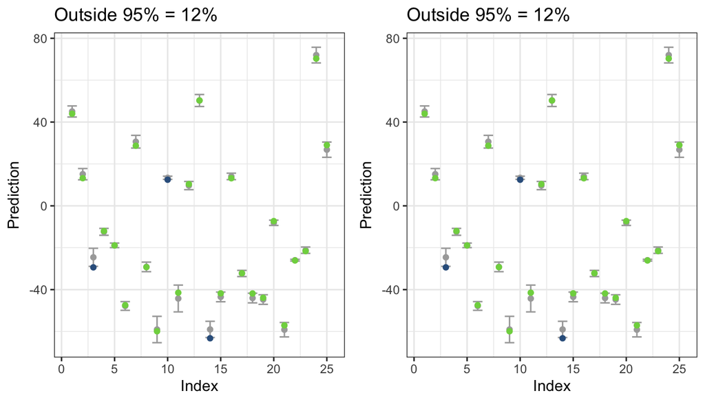

The default is `TRUE`.